# Data Mining on Bank Marketing Data

Stephan Sprenger

25 October 2014

# Introduction

The data investigated in this small workbook goes back to *S. Moro, P. Cortez and P. Rita. A Data-Driven Approach to Predict the Success of Bank Telemarketing. Decision Support Systems, Elsevier, 62:22-31, June 2014*  
The data is available from the [UCI Machine Learning Repository](https://archive.ics.uci.edu/ml/datasets/Bank+Marketing).  
Several data sets are available; we will use `bank-additional-full.csv`.  
An earlier paper from the authors is [*Moro, Cortez, Laureano: A data mining approach for bank telemarketing using the rminer package and r tool*](http://bru-unide.iscte.pt/RePEc/pdfs/13-06.pdf), which is free for download.

The purpose of this workbook to apply different machine learning algorithms to the data problem. The software `R` will be used in conjunction with the package `caret`.

# Data Preparation

The data is being loaded (again, we will use the `bank-additional-full.csv`).  
Investigation shows that the data needs to be prepared for analysis. The following steps are performed:

- the financial indicators are “factor, while we would want to have them as numeric for analysis. Therefore this data is transformed.
- We also understand that there are “unknown” data in several variables. We could replace these with NAs; however some algorithms (like Naive Bayes) would struggle. Given that on some of these variables there are many unknowns (like for `pdays`) we will leave the unknown observations as an own category “unknown”.
- The variable `pdays` has a value of 999 for ‘not available’; wee will set this to “unknown” as well.

One important change we make is with regards to the the variable `duration`. It indicates the length of a call. This might be interesting for analysis, but difficult for prediction: In a prediction task we do not know the duration of a call before it actually takes place.  
Therefore `duration` is being excluded from the set of predictors. Researchers who included it found this variable to be higly predictive (which is not surprising).

Also the data set is split into a training set (80%) and a test set (20%).

```r
library(caret)
library(pROC)
library(klaR)
library(dplyr)
bank.raw <- read.csv2(file="bank-additional-full.csv")
str(bank.raw)
bank <- bank.raw
bank$job <- factor(gsub("\\-", "", bank$job))
bank[,16:20] <- apply(bank[,16:20], 2, function (x) as.numeric(as.character(x)))
#bank[bank=="unknown"] <- NA
bank <- droplevels(bank)
bank[bank$pdays==999,"pdays"] <- "unknown"
bank$pdays <- as.factor(bank$pdays)
summary(bank)
names(bank)[names(bank)=="y"] <- "success"
bank$success <- factor(bank$success, levels=c("yes", "no"))

bank <- subset(bank, select=-c(duration))

trainIndex <- createDataPartition(bank$success, p=0.8, list=FALSE, times=1)
bank.train <- bank[trainIndex,]
bank.test <- bank[-trainIndex,]
```

# Modelling

We do not perform any feature engineering resp. feature selction. This, however, would be an important step, as can be seen in [Mores, Cortez, Rita].

We will fit the following models using the `caret`-package:

1. CART
2. C50
3. Conditional Inference Trees
4. Logistic Regression
5. Naive Bayes
6. Neural Net

10-fold cross-validation is performed on the traing set. The choice of model parameters is optimzed with regards to ROC.

The final evaluation happens based on the “area under the ROC-curve” AUC on the test set.

```r
bank.train.data <- subset(bank.train, select=-c(success), drop=TRUE)
bank.train.class <- subset(bank.train, select=c(success), drop=TRUE)
bank.test.data <- subset(bank.test, select=-c(success), drop=TRUE)
bank.test.class <- subset(bank.test, select=c(success), drop=TRUE)


cvCtrl <- trainControl(method="cv", classProbs=TRUE, summaryFunction=twoClassSummary, verboseIter=TRUE)


fit.rpart <- train(bank.train.data, bank.train.class, method="rpart", trControl=cvCtrl, metric="ROC", tuneLength = 10)
#load("CART_CV_10Iter.RData")
predict.rpart <- predict(fit.rpart)
confusionMatrix(predict.rpart, bank.train.class, positive="yes")
predict.rpart <- predict(fit.rpart, type = "prob")
(auc.rpart <- auc(bank.train.class, predict.rpart$yes))
predict.rpart <- predict(fit.rpart, bank.test.data, type = "prob")
(auc.rpart <- auc(bank.test.class, predict.rpart$yes))



fit.c50 <- train(bank.train.data, bank.train.class, method="C5.0", trControl=cvCtrl, metric="ROC", tuneLength = 10)
#load(file="C50_CV_10Iter.RData")
predict.c50 <- predict(fit.c50)
confusionMatrix(predict.c50, bank.train.class, positive="yes")
predict.c50 <- predict(fit.c50, type = "prob")
(auc.c50 <- auc(bank.train.class, predict.c50$yes))
predict.c50 <- predict(fit.c50, bank.test.data, type="prob")
(auc.c50 <- auc(bank.test.class, predict.c50$yes))


fit.ctree <- train(bank.train.data, bank.train.class, method="ctree", trControl=cvCtrl, metric="ROC")
#load(file = "Ctree_CV_10Iter.RData")
predict.ctree <- predict(fit.ctree)
confusionMatrix(predict.ctree, bank.train.class, positive="yes")
predict.ctree <- predict(fit.ctree, type = "prob")
(auc.ctree <- auc(bank.train.class, predict.ctree$yes))
predict.ctree <- predict(fit.ctree, bank.test.data, type="prob")
(auc.ctree <- auc(bank.test.class, predict.ctree$yes))

bank.train.dummy <- predict(dummyVars(success ~ . ,data=bank.train), newdata=bank.train)
bank.train.dummy <- data.frame(bank.train.dummy, success=factor(bank.train$success))
bank.test.dummy <- predict(dummyVars(success ~ . ,data=bank.test), newdata=bank.test)
bank.test.dummy <- data.frame(bank.test.dummy, success=factor(bank.test$success))


fit.logit <- train(success ~ ., data=bank.train.dummy, method="glm", family=binomial, trControl=cvCtrl, metric="ROC", tuneLength=1)
#load(file = "Logit_CV_10Iter.RData")
predict.logit <- predict.train(fit.logit)
confusionMatrix(predict.logit, bank.train.class, positive="yes")
predict.logit <- predict(fit.logit, type = "prob")
(auc.logit <- auc(bank.train.dummy$success, predict.logit$yes))
predict.logit <- predict(fit.logit, bank.test.dummy, type="prob")
(auc.logit <- auc(bank.test.dummy$success, predict.logit$yes))

fit.nb <- train(bank.train.data, bank.train.class, method="nb", trControl=cvCtrl, metric="ROC", tuneLength=10)
#load(file = "NB_CV_10Iter.RData")
predict.nb <- predict(fit.nb)
confusionMatrix(predict.nb, bank.train.class, positive="yes")
predict.nb <- predict(fit.nb, type = "prob")
(auc.nb <- auc(bank.train.class, predict.nb$yes))
predict.nb <- predict(fit.nb, bank.test.data, type="prob")
(auc.nb <- auc(bank.test.class, predict.nb$yes))


fit.nn <- train(success ~ ., data=bank.train.dummy, method="nnet", trControl=cvCtrl, metric="ROC", tuneLength=10)
#load(file = "NN_CV_10Iter.RData")
predict.nn <- predict(fit.nn)
confusionMatrix(predict.nn, bank.train.class, positive="yes")
predict.nn <- predict(fit.nn, type = "prob")
(auc.nn <- auc(bank.train.class, predict.nn$yes))
predict.nn <- predict(fit.nn, bank.test.dummy, type="prob")
(auc.nn <- auc(bank.test.class, predict.nn$yes))

#rm(list=c("fit.ctree", "fit.logit", "fit.nb", "fit.nn", "fit.rpart"))
```

```r
load(file="Banking.RData")
library(pROC)
library(caret)
plot.roc(bank.test.class, predict.rpart$yes, col="green")
```

```
##
## Call:
## plot.roc.default(x = bank.test.class, predictor = predict.rpart$yes,     col = "green")
##
## Data: predict.rpart$yes in 928 controls (bank.test.class yes) > 7309 cases (bank.test.class no).
## Area under the curve: 0.7451
```

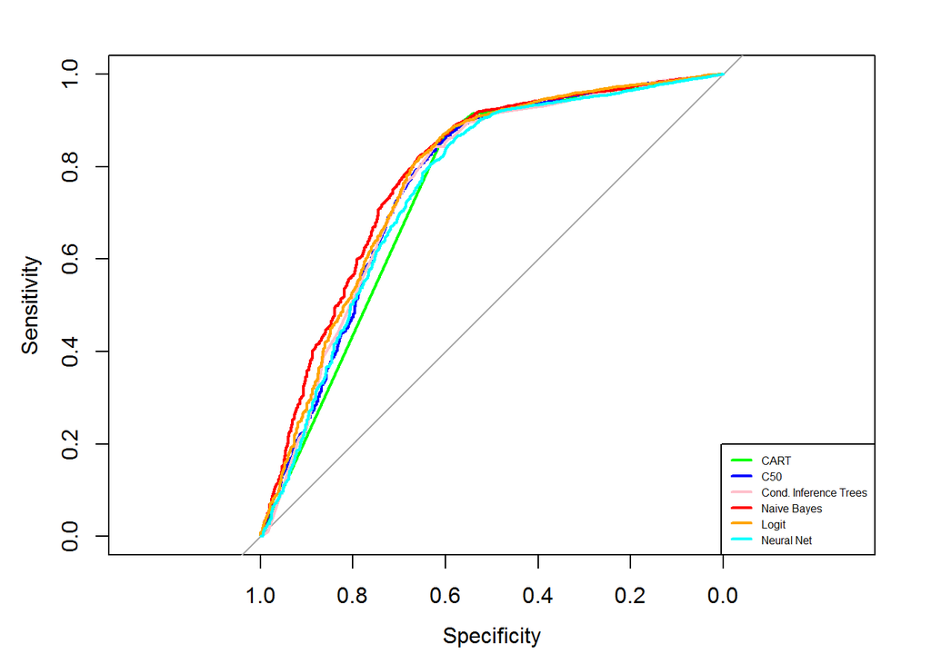

```r
lines.roc(bank.test.class, predict.c50$yes, col="blue")
lines.roc(bank.test.class, predict.ctree$yes, col="pink")
lines.roc(bank.test.class, predict.nb$yes, col="red")
lines.roc(bank.test.class, predict.logit$yes, col="orange")
lines.roc(bank.test.class, predict.nn$yes, col="cyan")
legend("bottomright", legend=c("CART", "C50", "Cond. Inference Trees", "Naive Bayes", "Logit", "Neural Net"), col=c("green", "blue", "pink", "red", "orange", "cyan"), lwd=2, cex=0.5)
```

```r
library(dplyr)
#auc <- rbind(C50=auc.c50, CART=auc.rpart, ctree=auc.ctree, Logit=auc.logit, NaiveBayes=auc.nb, NeuralNet=auc.nn)
#auc <- data.frame(Model=row.names(auc), AUC=auc)
(auc <- arrange(auc, desc(AUC)))
```

[output not shown]

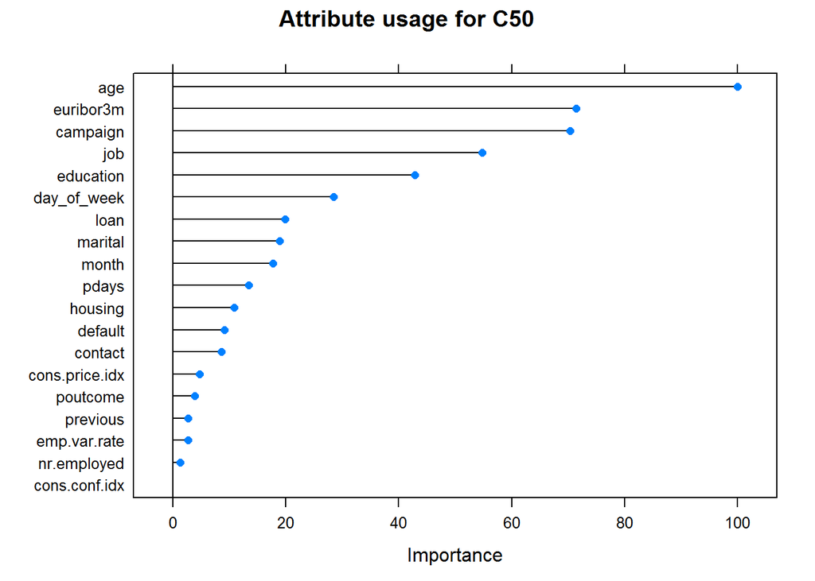

```r
# plot(varImp(fit.rpart))
plot(varImp(fit.c50, metric="splits"), main="Attribute usage for C50")
```

```r
# plot(varImp(fit.ctree))
# plot(varImp(fit.nb))
# plot(varImp(fit.logit))
# plot(varImp(fit.nn))
```